# Analysis of unmapped genomics reads and implication in genomic composition

```
INFO [2019-11-01 14:55:29] Current working folder: /home/carlos/Projects/BIO18025-201808-FunMG-Kaiko/doc/20191001-Nomap-Analysis
```

## Purpose

This analysis attempts to identify species that have been missed in the construction of the individual genomic references. It follows the same line of the analysis for transcriptomic data. Genomic data is Paired End, and we need to do slight adjustments.

The overall scheme of the analysis is:

1. Use Global Genomic Reference (GGR) constructed for Tx data.
2. Align the genomic pairs unmapped concordantly in each timepoint against the GGR
3. Filter uniquely mapping pairs and extract identified genomic sequences (species)
4. Aggregate at individual level
5. For each individual, exclude from this list species already in the individual genomic reference
6. Do similar analysis on unmapped Gx reads and decide if individual genomic reference should be augmented and remapped in Gx and Tx.

In step 5, there should be little to no species known (we are using reads that did not map to begin with). If there are known species –to the individual– then, why ?

By a quick look at the nomap alignment stats a few timepoints (seem grouped by individual, e.g. all timepoints of individual are similar) have a large number of reads that are **unmapped** after this process.  
This suggests some species have not been identified yet and account for a large number of reads for the individual.

Mapper used is `Bowtie2`, under the assumption that splicing plays a minimal role.

## Alignment

```
INFO [2019-11-01 14:55:30] There are 734 alignment log files, and 7 timepoints/samples in the remove list
INFO [2019-11-01 14:55:30] After removing 13 predefined dubious timepoints, 721 timepoints remain (103 samples)
```

| tp | sample | PE.tot | PE.uniq | PE.mult | PE.noconc | map.pe | logfile |
| --- | --- | --- | --- | --- | --- | --- | --- |
| C3001-CSM5MCXD | C3001 | 4202820 | 415792 | 558120 | 3228908 | 0.23173 | /home/carlos/Projects/BIO18025-201808-FunMG-Kaiko/data/20191030-align-noconc//C3001-CSM5MCXD_align.log |
| C3001-CSM67UA2 | C3001 | 3326128 | 331424 | 509241 | 2485463 | 0.25275 | /home/carlos/Projects/BIO18025-201808-FunMG-Kaiko/data/20191030-align-noconc//C3001-CSM67UA2_align.log |
| C3001-CSM79HGP | C3001 | 5003496 | 474054 | 735588 | 3793854 | 0.24176 | /home/carlos/Projects/BIO18025-201808-FunMG-Kaiko/data/20191030-align-noconc//C3001-CSM79HGP_align.log |
| C3002-CSM5MCVN | C3002 | 3501991 | 464518 | 1061930 | 1975543 | 0.43588 | /home/carlos/Projects/BIO18025-201808-FunMG-Kaiko/data/20191030-align-noconc//C3002-CSM5MCVN_align.log |
| C3002-CSM67UBH | C3002 | 4639678 | 627918 | 1246528 | 2765232 | 0.40400 | /home/carlos/Projects/BIO18025-201808-FunMG-Kaiko/data/20191030-align-noconc//C3002-CSM67UBH_align.log |
| C3002-CSM67UBN | C3002 | 2976148 | 380975 | 863158 | 1732015 | 0.41803 | /home/carlos/Projects/BIO18025-201808-FunMG-Kaiko/data/20191030-align-noconc//C3002-CSM67UBN_align.log |
| C3002-CSM79HJW | C3002 | 5010232 | 690793 | 1479935 | 2839504 | 0.43326 | /home/carlos/Projects/BIO18025-201808-FunMG-Kaiko/data/20191030-align-noconc//C3002-CSM79HJW_align.log |
| C3003-CSM5FZ4M | C3003 | 3513967 | 583557 | 708230 | 2222180 | 0.36762 | /home/carlos/Projects/BIO18025-201808-FunMG-Kaiko/data/20191030-align-noconc//C3003-CSM5FZ4M_align.log |
| C3003-CSM5MCWQ | C3003 | 3032940 | 342291 | 400657 | 2289992 | 0.24496 | /home/carlos/Projects/BIO18025-201808-FunMG-Kaiko/data/20191030-align-noconc//C3003-CSM5MCWQ_align.log |
| C3003-CSM67UBZ | C3003 | 3519779 | 520970 | 558322 | 2440487 | 0.30664 | /home/carlos/Projects/BIO18025-201808-FunMG-Kaiko/data/20191030-align-noconc//C3003-CSM67UBZ_align.log |

[output cut: 711 more lines]

| Column | Description |
| --- | --- |
| tp | Timepoint ID |
| sample | Patient ID |
| PE.tot | Total originally unmapped pairs (Paired End) |
| PE.uniq | Number of uniquely mapping to global ref (PE) |
| PE.mult | Number of multiply mapping to global ref (PE) |
| PE.noconc | Number of unmapped to global ref (PE) |
| map.se | Mapping efficiency $\frac{(PE_{uniq}+PE_{mult})}{PE_{tot}}$ |
| logfile | Ditto |

### Plot of the alignment stats per timepoint

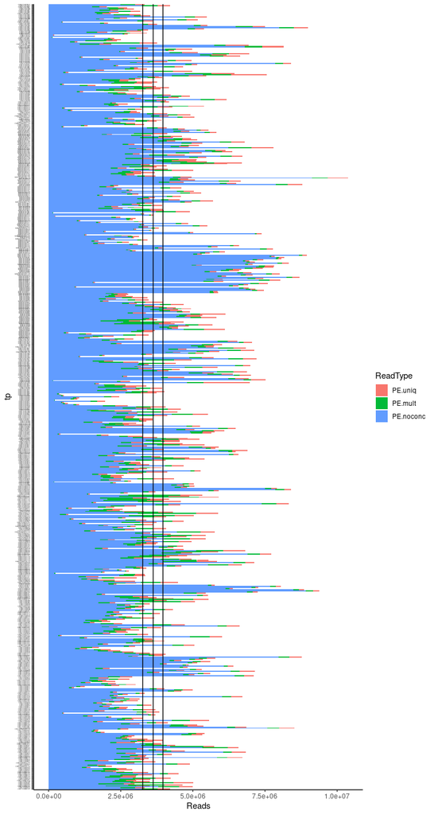

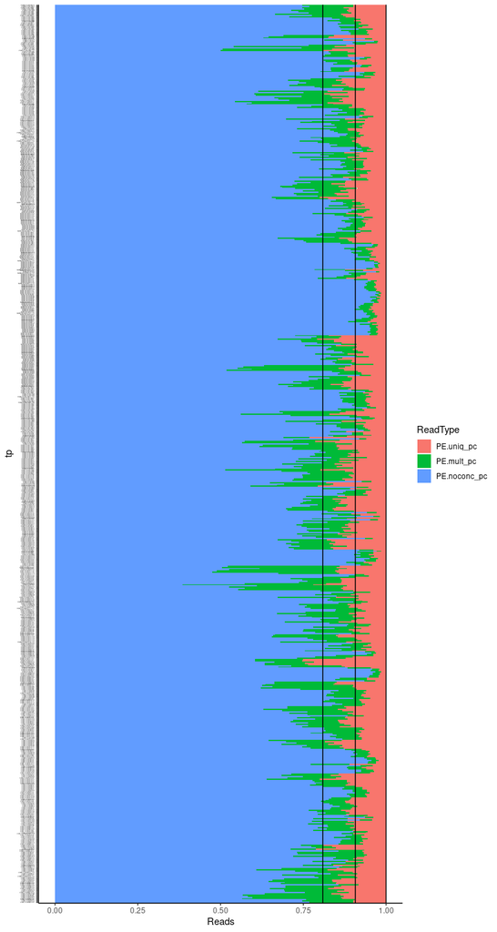

### Summary by sample

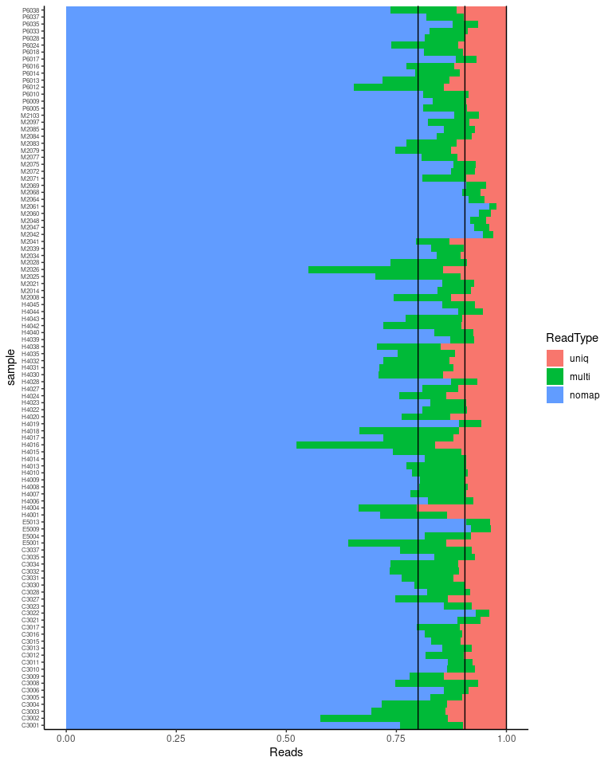

We now plot the ratio of uniquely mapping reads in this global reference realignment to the total number of original uniquely mapping reads against the individual genomes. This should be a proxy of the missing species read fraction in the data.

[output not shown]

In the combined table, columns are:

| Column | Description |
| --- | --- |
| tp | sample-timepoint ID |
| sample | Patient ID |
| PE.tot | Total number of sequenced pairs (original, Paired End) |
| PE.uniq | Number of uniquely mapping to individual ref (PE) |
| PE.mult | Number of multiply mapping to individual ref (PE) |
| PE.nomap | Number of noconcordant to individual ref (PE) |
| map.pe | Mapping efficiency $\frac{(S_{uniq}+S_{mult})}{S_{tot}}$ |
| logfile | Ditto |
| i.PE.tot | Total number of unmapped pairs global ref (Paired End) |
| i.PE.uniq | Number of uniquely mapping to global ref (PE) |
| i.PE.mult | Number of multiply mapping to global ref (PE) |
| i.PE.nomap | Number of unmapped to global ref (PE) |
| i.map.pe | Mapping efficiency $\frac{(i.S_{uniq}+i.S_{mult})}{i.S_{tot}}$ |
| i.logfile | for the global ref alignment |
| numfrac | Ratio of newly uniquely mapped to original uniquely mapped $\frac{i.S_{uniq}}{S_{uniq}}$ |
| nmap.pe | Combined new mapping efficiency $\frac{(S_{uniq}+S_{mult}+i.S_{uniq}+i.S_{mult})}{S_{tot}}$ |

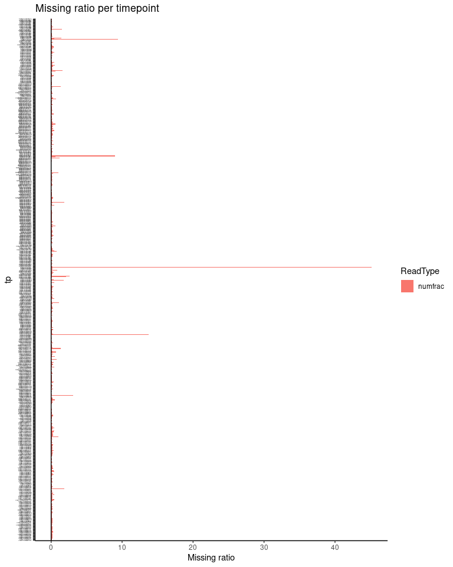

Values of numfrac larger than one mean that the alignment to the global ref aligns (uniquely) more reads than the uniquely aligned against the individual genome ref.

Just in case we want to know which timepoint / sample the spike is:

| tp | sample | PE.tot | PE.uniq | PE.mult | PE.noconc | map.pe | logfile | i.sample | i.PE.tot | i.PE.uniq | i.PE.mult | i.PE.noconc | i.map.pe | i.logfile | numfrac | nmap.pe |
| --- | --- | --- | --- | --- | --- | --- | --- | --- | --- | --- | --- | --- | --- | --- | --- | --- |
| C3013-CSM7KONU | C3013 | 915711 | 249281 | 144844 | 521586 | 0.43040 | /home/carlos/Projects/BIO18025-201808-FunMG-Kaiko/data/20190522-QCData-rcg/mtg//C3013-CSM7KONU_align.log | C3013 | 3843196 | 462471 | 329956 | 3050769 | 0.20619 | /home/carlos/Projects/BIO18025-201808-FunMG-Kaiko/data/20191030-align-noconc//C3013-CSM7KONU_align.log | 1.855 | 1.2958 |
| C3031-CSM79HR8 | C3031 | 1525314 | 259561 | 815057 | 450696 | 0.70452 | /home/carlos/Projects/BIO18025-201808-FunMG-Kaiko/data/20190522-QCData-rcg/mtg//C3031-CSM79HR8_align.log | C3031 | 2138978 | 268581 | 315024 | 1555373 | 0.27284 | /home/carlos/Projects/BIO18025-201808-FunMG-Kaiko/data/20191030-align-noconc//C3031-CSM79HR8_align.log | 1.035 | 1.0871 |
| H4006-HSM5MD7O | H4006 | 285604 | 27490 | 23925 | 234189 | 0.18002 | /home/carlos/Projects/BIO18025-201808-FunMG-Kaiko/data/20190522-QCData-rcg/mtg//H4006-HSM5MD7O_align.log | H4006 | 2776337 | 84305 | 40327 | 2651705 | 0.04489 | /home/carlos/Projects/BIO18025-201808-FunMG-Kaiko/data/20191030-align-noconc//H4006-HSM5MD7O_align.log | 3.067 | 0.6164 |
| H4017-HSM7CYYB | H4017 | 6602453 | 431456 | 4523206 | 1647791 | 0.75043 | /home/carlos/Projects/BIO18025-201808-FunMG-Kaiko/data/20190522-QCData-rcg/mtg//H4017-HSM7CYYB_align.log | H4017 | 4000885 | 599491 | 1502303 | 1899091 | 0.52533 | /home/carlos/Projects/BIO18025-201808-FunMG-Kaiko/data/20191030-align-noconc//H4017-HSM7CYYB_align.log | 1.389 | 1.0688 |
| H4019-HSM7J4PK | H4019 | 256241 | 29047 | 37284 | 189910 | 0.25886 | /home/carlos/Projects/BIO18025-201808-FunMG-Kaiko/data/20190522-QCData-rcg/mtg//H4019-HSM7J4PK_align.log | H4019 | 2500043 | 399907 | 296067 | 1804069 | 0.27838 | /home/carlos/Projects/BIO18025-201808-FunMG-Kaiko/data/20191030-align-noconc//H4019-HSM7J4PK_align.log | 13.768 | 2.9750 |
| H4027-HSMA33O3 | H4027 | 1693756 | 373120 | 910972 | 409664 | 0.75813 | /home/carlos/Projects/BIO18025-201808-FunMG-Kaiko/data/20190522-QCData-rcg/mtg//H4027-HSMA33O3_align.log | H4027 | 5751180 | 397065 | 451627 | 4902488 | 0.14757 | /home/carlos/Projects/BIO18025-201808-FunMG-Kaiko/data/20191030-align-noconc//H4027-HSMA33O3_align.log | 1.064 | 1.2592 |
| H4035-HSM7J4K4 | H4035 | 355331 | 63325 | 68525 | 223481 | 0.37106 | /home/carlos/Projects/BIO18025-201808-FunMG-Kaiko/data/20190522-QCData-rcg/mtg//H4035-HSM7J4K4_align.log | H4035 | 1064479 | 114525 | 113328 | 836626 | 0.21405 | /home/carlos/Projects/BIO18025-201808-FunMG-Kaiko/data/20191030-align-noconc//H4035-HSM7J4K4_align.log | 1.809 | 1.0123 |
| H4035-HSMA33MG | H4035 | 1091349 | 254691 | 380309 | 456349 | 0.58185 | /home/carlos/Projects/BIO18025-201808-FunMG-Kaiko/data/20190522-QCData-rcg/mtg//H4035-HSMA33MG_align.log | H4035 | 3735645 | 541974 | 521563 | 2672108 | 0.28470 | /home/carlos/Projects/BIO18025-201808-FunMG-Kaiko/data/20191030-align-noconc//H4035-HSMA33MG_align.log | 2.128 | 1.5564 |
| H4035-HSMA33MK | H4035 | 904471 | 218807 | 310656 | 375008 | 0.58538 | /home/carlos/Projects/BIO18025-201808-FunMG-Kaiko/data/20190522-QCData-rcg/mtg//H4035-HSMA33MK_align.log | H4035 | 4005689 | 571900 | 559060 | 2874729 | 0.28234 | /home/carlos/Projects/BIO18025-201808-FunMG-Kaiko/data/20191030-align-noconc//H4035-HSMA33MK_align.log | 2.614 | 1.8358 |
| H4039-HSM7J4LP | H4039 | 201473 | 10745 | 25379 | 165349 | 0.17930 | /home/carlos/Projects/BIO18025-201808-FunMG-Kaiko/data/20190522-QCData-rcg/mtg//H4039-HSM7J4LP_align.log | H4039 | 6942050 | 485185 | 232614 | 6224251 | 0.10340 | /home/carlos/Projects/BIO18025-201808-FunMG-Kaiko/data/20191030-align-noconc//H4039-HSM7J4LP_align.log | 45.154 | 3.7421 |

[output cut: 8 more lines]

```
INFO [2019-11-01 14:55:35] Timepoints for which numfrac > .5
```

Using a threshold twice as big as in Tx to get a similar number of timepoints. Not much correspondence to sample-tp that gave high number in transcriptome.

Summarise by sample:

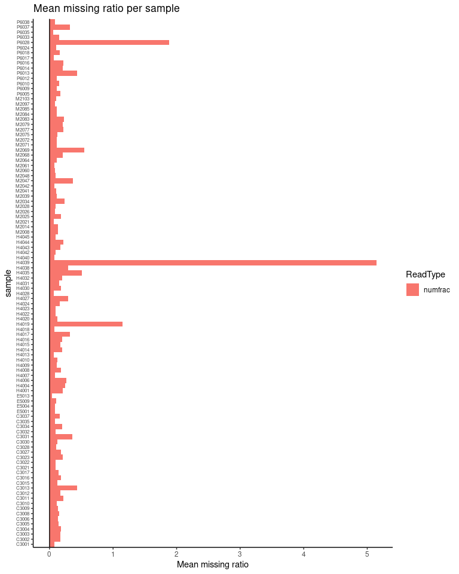

In these previous two figures, the ratio is the proportion of previously unmapped reads to original uniquely mapped reads when using the individual reference. A value of .25 means that the newly identified reads are one fourth of previously identified (uniquely mapping).

Another way of looking at the missing species is by plotting the differential mapping efficiency, this will include the overall effect of reads multiply mapping as well.

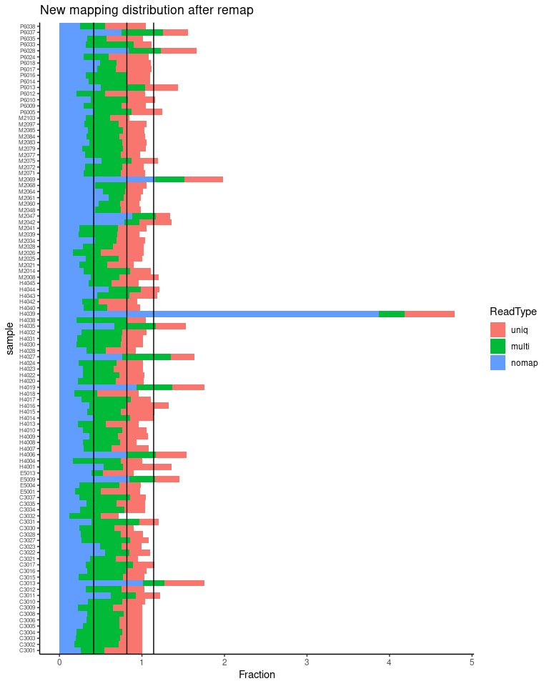

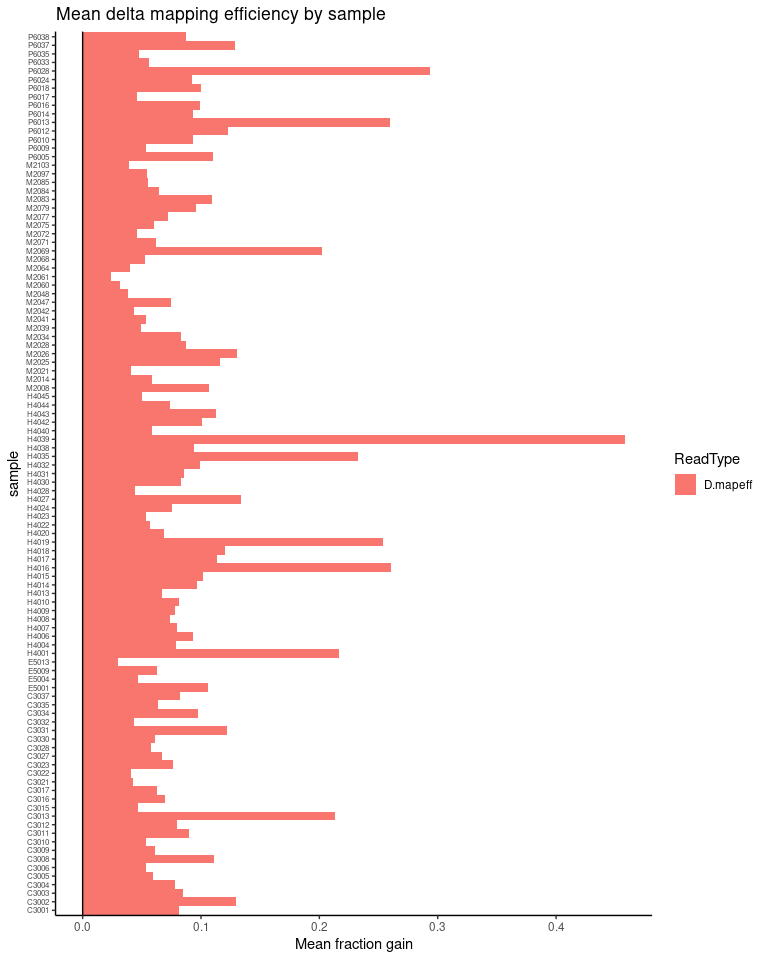

## Detection of new species per individual

Decision on whether update the individual reference is based on a threshold on newly identified reads ratio. A value of .2 means we now uniquely map at least one fifth more than originally.

```
INFO [2019-11-01 14:55:36] Using ratio 0.5 to detect new species: 5 samples exceed the threshold
```

| sample | numfrac |
| --- | --- |
| H4035 | 0.5122 |
| M2069 | 0.5442 |
| H4019 | 1.1477 |
| P6028 | 1.8827 |
| H4039 | 5.1441 |

For comparison, the mean delta efficiency and samples exceeding 20% gain in efficiency gain are:

```
INFO [2019-11-01 14:55:36] Using a fractional gain in mapping efficiency of 0.2 or more: 9 samples exceed the threshold. Intersection: 5
```

| sample | uniq | multi | nomap | D.mapeff |
| --- | --- | --- | --- | --- |
| H4016 | 0.5143 | 0.4468 | 0.3594 | 0.2603 |
| P6013 | 0.3944 | 0.5370 | 0.5012 | 0.2597 |
| H4001 | 0.5866 | 0.2342 | 0.5377 | 0.2169 |
| H4035 | 0.3586 | 0.5063 | 0.6634 | 0.2326 |
| P6028 | 0.4346 | 0.3903 | 0.8367 | 0.2932 |
| H4019 | 0.3905 | 0.4332 | 0.9338 | 0.2535 |
| C3013 | 0.4846 | 0.2587 | 1.0111 | 0.2131 |
| M2069 | 0.4707 | 0.3501 | 1.1609 | 0.2024 |
| H4039 | 0.5981 | 0.3168 | 3.8702 | 0.4582 |

In order to detect which new species are there for the individual, we will extract the sequences information from the `.bam` file header and compare to the species list in the original reference definition file. Then we need to count the new reads on the new species and filter the very low abundance ones.

We should update the individual references, rebuild and remap. We will instead, as a first approximation, add these new reads to the previous and redo the count matrix. The difference would be minimal, and expected only in the fraction of multiply mapped reads.

[output not shown]

Validity checks: All sequence levels should be same, but sequences not. We test last using set intersection

```
INFO [2019-10-31 16:56:52] "Chromosomal" sequences are the same for all timepoints: TRUE
INFO [2019-10-31 16:56:52] Lengths of sequence lists are the same: all:FALSE
```

Process references extracting list of chromosomal sequences. We only get those references accounting for 0.8 of new uniquely mapping pairs in each timepoint, and then simplify to list each only once.

```
INFO [2019-10-31 16:57:56] Sample: H4035: 33 new refs, 33 total
INFO [2019-10-31 16:57:56] Sample: H4035: 41 new refs, 42 total
INFO [2019-10-31 16:57:56] Sample: H4035: 26 new refs, 44 total
INFO [2019-10-31 16:57:56] Sample: H4035: 55 new refs, 63 total
INFO [2019-10-31 16:57:56] Sample: H4035: 54 new refs, 79 total
INFO [2019-10-31 16:57:57] Sample: H4035: 64 new refs, 87 total
INFO [2019-10-31 16:57:57] Sample: H4035: 47 new refs, 91 total
INFO [2019-10-31 16:57:57] Sample: H4035: 49 new refs, 92 total
INFO [2019-10-31 16:57:57] Sample: H4035: 69 new refs, 98 total
INFO [2019-10-31 16:57:57] Sample: H4035: 64 new refs, 100 total
INFO [2019-10-31 16:57:57] Sample: H4035: 72 new refs, 104 total
INFO [2019-10-31 16:57:57] Sample: H4035: 71 new refs, 111 total
INFO [2019-10-31 16:57:57] Sample: H4035: 62 new refs, 117 total
INFO [2019-10-31 16:57:57] Sample: H4035: 52 new refs, 118 total
INFO [2019-10-31 16:57:57] Sample: H4035: 45 new refs, 118 total
INFO [2019-10-31 16:57:57] Sample: H4035: 50 new refs, 119 total
INFO [2019-10-31 16:57:57] Wrote new refs to /home/carlos/Projects/BIO18025-201808-FunMG-Kaiko/rcg/genomes/addgenolist-gx-H4035.txt
INFO [2019-10-31 16:57:58] Sample: M2069: 89 new refs, 89 total
INFO [2019-10-31 16:57:58] Sample: M2069: 83 new refs, 124 total
INFO [2019-10-31 16:57:58] Sample: M2069: 88 new refs, 129 total
INFO [2019-10-31 16:57:58] Sample: M2069: 38 new refs, 130 total
INFO [2019-10-31 16:57:58] Sample: M2069: 65 new refs, 132 total
INFO [2019-10-31 16:57:58] Sample: M2069: 71 new refs, 139 total
INFO [2019-10-31 16:57:58] Sample: M2069: 86 new refs, 156 total
INFO [2019-10-31 16:57:58] Sample: M2069: 67 new refs, 161 total
INFO [2019-10-31 16:57:58] Sample: M2069: 86 new refs, 162 total
INFO [2019-10-31 16:57:58] Sample: M2069: 88 new refs, 168 total
INFO [2019-10-31 16:57:58] Sample: M2069: 72 new refs, 169 total
INFO [2019-10-31 16:57:58] Sample: M2069: 73 new refs, 172 total
INFO [2019-10-31 16:57:58] Sample: M2069: 74 new refs, 175 total
INFO [2019-10-31 16:57:58] Sample: M2069: 72 new refs, 175 total
INFO [2019-10-31 16:57:59] Sample: M2069: 77 new refs, 176 total
INFO [2019-10-31 16:57:59] Sample: M2069: 42 new refs, 176 total
INFO [2019-10-31 16:57:59] Sample: M2069: 67 new refs, 176 total
INFO [2019-10-31 16:57:59] Sample: M2069: 116 new refs, 206 total
INFO [2019-10-31 16:57:59] Sample: M2069: 70 new refs, 208 total
INFO [2019-10-31 16:57:59] Sample: M2069: 86 new refs, 210 total
INFO [2019-10-31 16:57:59] Sample: M2069: 14 new refs, 212 total
INFO [2019-10-31 16:57:59] Wrote new refs to /home/carlos/Projects/BIO18025-201808-FunMG-Kaiko/rcg/genomes/addgenolist-gx-M2069.txt
INFO [2019-10-31 16:57:59] Sample: H4019: 142 new refs, 142 total
```

[output cut: 15 more lines]

```
INFO [2019-10-31 16:58:00] Sample: P6028: 3 new refs, 115 total
INFO [2019-10-31 16:58:00] Sample: P6028: 5 new refs, 120 total
INFO [2019-10-31 16:58:00] Sample: P6028: 10 new refs, 121 total
INFO [2019-10-31 16:58:00] Sample: P6028: 29 new refs, 128 total
INFO [2019-10-31 16:58:00] Wrote new refs to /home/carlos/Projects/BIO18025-201808-FunMG-Kaiko/rcg/genomes/addgenolist-gx-P6028.txt
INFO [2019-10-31 16:58:00] Sample: H4039: 72 new refs, 72 total
INFO [2019-10-31 16:58:00] Sample: H4039: 5 new refs, 74 total
INFO [2019-10-31 16:58:00] Sample: H4039: 6 new refs, 75 total
INFO [2019-10-31 16:58:00] Sample: H4039: 7 new refs, 76 total
INFO [2019-10-31 16:58:00] Sample: H4039: 63 new refs, 105 total
INFO [2019-10-31 16:58:00] Sample: H4039: 67 new refs, 110 total
INFO [2019-10-31 16:58:01] Sample: H4039: 6 new refs, 110 total
INFO [2019-10-31 16:58:01] Sample: H4039: 22 new refs, 110 total
INFO [2019-10-31 16:58:01] Sample: H4039: 79 new refs, 119 total
INFO [2019-10-31 16:58:01] Wrote new refs to /home/carlos/Projects/BIO18025-201808-FunMG-Kaiko/rcg/genomes/addgenolist-gx-H4039.txt
```

```
INFO [2019-10-31 17:56:22] Samples listed in both Gx and Tx with missing species:

[1] "H4019"
```

Not much of a coincidence.